# ColtExpress December 2021

The results in the tabs below show the MCTS parameters optimised against each of three opponents:

- Random (RND)
- One Step Lookahead (OSLA) that optimises the score immediately after the next move
- An MCTS agent with 20ms computational budget per decision (Rollout and Tree depth of 10, K = 1.41, using classic Open-Loop UCB with SelfOnly search)

The data below are for each Opponent (RND, OSLA, MCTS, MultiNTBEA) using the default heuristic; plus for each player count (2P, 3P, 4P) on the same basis. On each tab there are three sets of information:

1. Win Rates. Each of the 30 NTBEA runs produces a single recommendation - 900 games are run using this setting to get a win rate. The reported win rate is the average of these 30 individual results. [No Win Rate is reported for MultiNTBEA runs, as there is no ‘standard’ opponent against which this can be measured.]
2. Fingerprints
3. p-Values for Chi-squared tests of homogeneity for each parameter. For ease of visualisation a hard threshold of a p-value less than 0.001 is used here.

The core conclusions are:

- Using the default heuristic gives a pretty dreadful player. It only wins 31% of 4-P games against a RND player for example!
- Rollout Length is the only significant parameter across all player counts and opponents: Colt Express needs long rollouts of 10+ for 2P and 30+ for 3/4P to play well (or at least as well as the weak heuristic allows).
- MultiNTBEA gives a very flat set of parameter recommendations. None of them are significant at the 0.001 level.

## Base Opponents

### RND

Mean Win rate over all NTBEA runs

| Type | 2P | 3P | 4P |
| --- | --- | --- | --- |
| Win Rate | 75% | 45% | 31% |

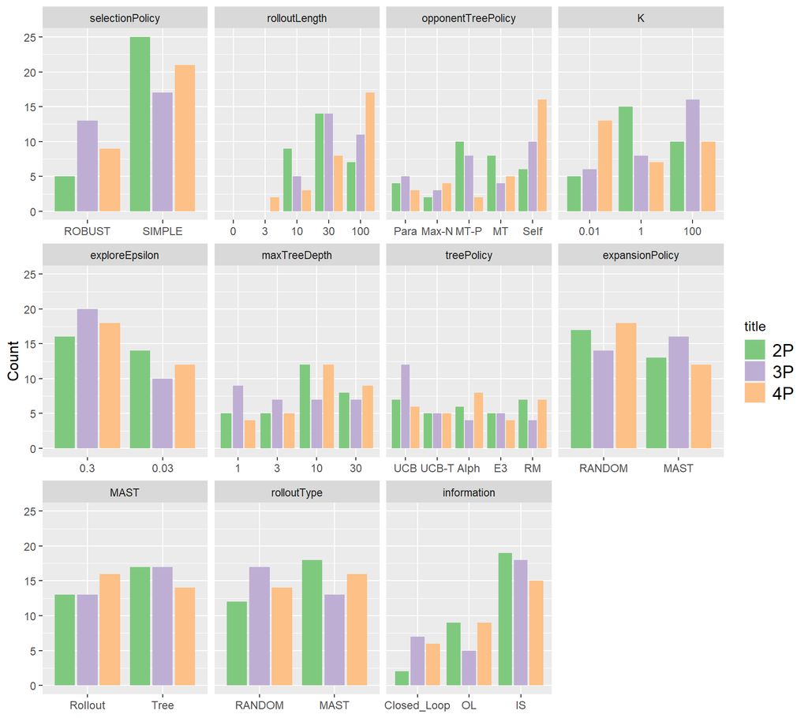

Significant p-Values on Chi-squared test for homogeneity - only extreme values highlighted

| Parameter | 2P | 3P | 4P | All |
| --- | --- | --- | --- | --- |
| selectionPolicy | p < 0.001 |  |  |  |
| rolloutLength | p < 0.001 | p < 0.001 | p < 0.001 | p < 0.001 |
| opponentTreePolicy |  |  | p < 0.001 |  |
| K |  |  |  |  |
| exploreEpsilon |  |  |  |  |
| maxTreeDepth |  |  |  |  |
| treePolicy |  |  |  |  |
| expansionPolicy |  |  |  |  |
| MAST |  |  |  |  |
| rolloutType |  |  |  |  |
| information | p < 0.001 |  |  | p < 0.001 |

### OSLA

Mean Win rate over all NTBEA runs

| Type | 2P | 3P | 4P |
| --- | --- | --- | --- |
| Win Rate | 77% | 44% | 31% |

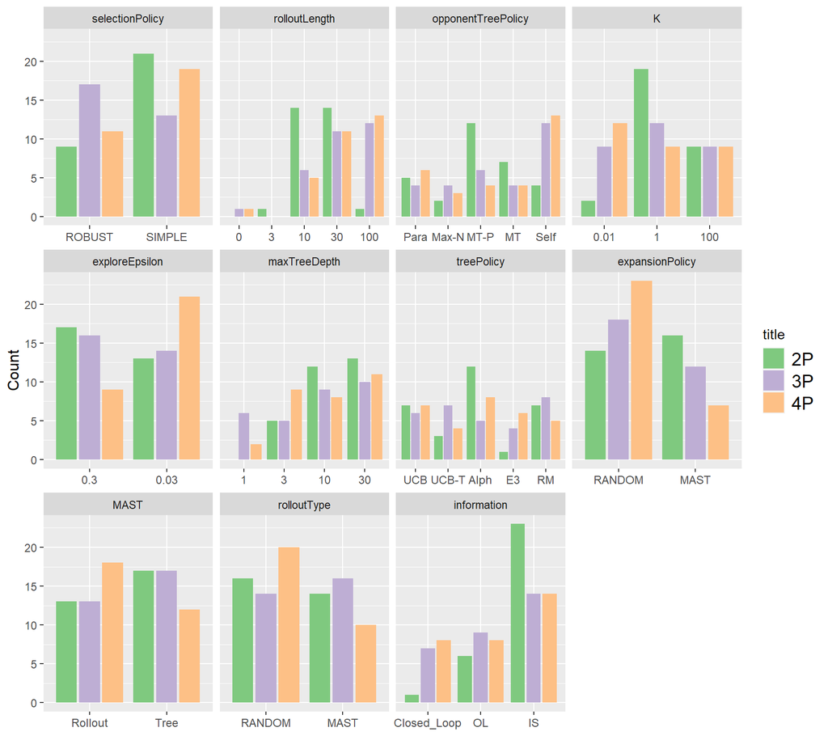

Significant p-Values on Chi-squared test for homogeneity - only extreme values highlighted

| Parameter | 2P | 3P | 4P | All |
| --- | --- | --- | --- | --- |
| selectionPolicy |  |  |  |  |
| rolloutLength | p < 0.001 | p < 0.001 | p < 0.001 | p < 0.001 |
| opponentTreePolicy |  |  |  |  |
| K | p < 0.001 |  |  |  |
| exploreEpsilon |  |  |  |  |
| maxTreeDepth |  |  |  |  |
| treePolicy |  |  |  |  |
| expansionPolicy |  |  |  |  |
| MAST |  |  |  |  |
| rolloutType |  |  |  |  |
| information | p < 0.001 |  |  | p < 0.001 |

### MCTS

Mean Win rate over all NTBEA runs

| Type | 2P | 3P | 4P |
| --- | --- | --- | --- |
| Win Rate | 51% | 33% | 25% |

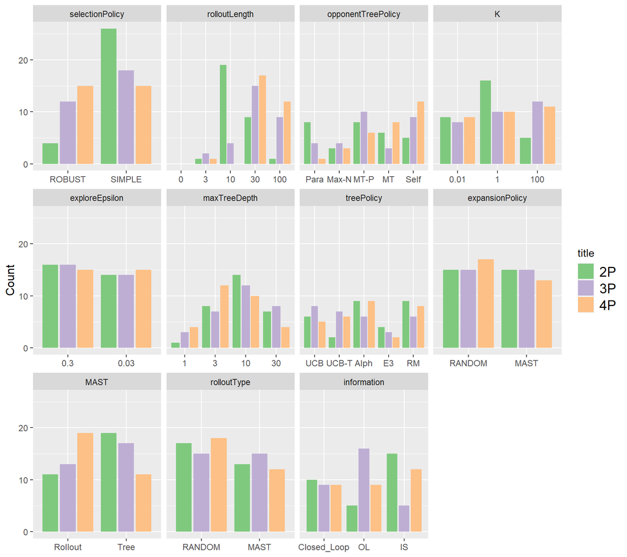

Significant p-Values on Chi-squared test for homogeneity - only extreme values highlighted

| Parameter | 2P | 3P | 4P | All |
| --- | --- | --- | --- | --- |
| selectionPolicy | p < 0.001 |  |  |  |
| rolloutLength | p < 0.001 | p < 0.001 | p < 0.001 | p < 0.001 |
| opponentTreePolicy |  |  |  |  |
| K |  |  |  |  |
| exploreEpsilon |  |  |  |  |
| maxTreeDepth |  |  |  |  |
| treePolicy |  |  |  |  |
| expansionPolicy |  |  |  |  |
| MAST |  |  |  |  |
| rolloutType |  |  |  |  |
| information |  |  |  |  |

### Multi

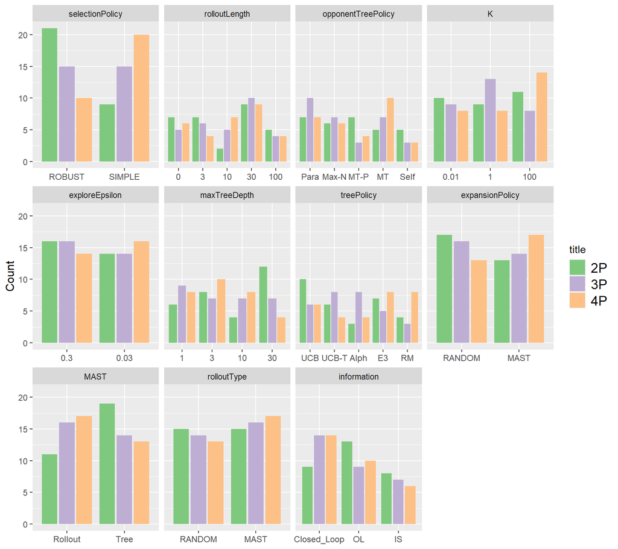

Significant p-Values on Chi-squared test for homogeneity - only extreme values highlighted

| Parameter | 2P | 3P | 4P | All |
| --- | --- | --- | --- | --- |
| selectionPolicy |  |  |  |  |
| rolloutLength |  |  |  |  |
| opponentTreePolicy |  |  |  |  |
| K |  |  |  |  |
| exploreEpsilon |  |  |  |  |
| maxTreeDepth |  |  |  |  |
| treePolicy |  |  |  |  |
| expansionPolicy |  |  |  |  |
| MAST |  |  |  |  |
| rolloutType |  |  |  |  |
| information |  |  |  |  |

### 2P

Mean Win rate over all NTBEA runs

| Type | MCTS | OSLA | RND |
| --- | --- | --- | --- |
| Win Rate | 51% | 77% | 75% |

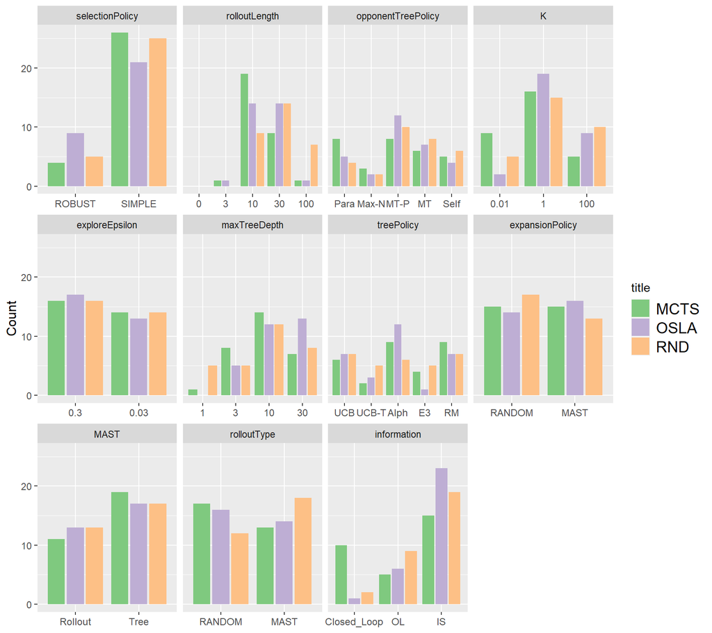

Significant p-Values on Chi-squared test for homogeneity - only extreme values highlighted

| Parameter | MCTS | OSLA | RND | All |
| --- | --- | --- | --- | --- |
| selectionPolicy | p < 0.001 |  | p < 0.001 | p < 0.001 |
| rolloutLength | p < 0.001 | p < 0.001 | p < 0.001 | p < 0.001 |
| opponentTreePolicy |  |  |  |  |
| K |  | p < 0.001 |  |  |
| exploreEpsilon |  |  |  |  |
| maxTreeDepth |  |  |  |  |
| treePolicy |  |  |  |  |
| expansionPolicy |  |  |  |  |
| MAST |  |  |  |  |
| rolloutType |  |  |  |  |
| information |  | p < 0.001 | p < 0.001 | p < 0.001 |

### 3P

Mean Win rate over all NTBEA runs

| Type | MCTS | OSLA | RND |
| --- | --- | --- | --- |
| Win Rate | 33% | 44% | 45% |

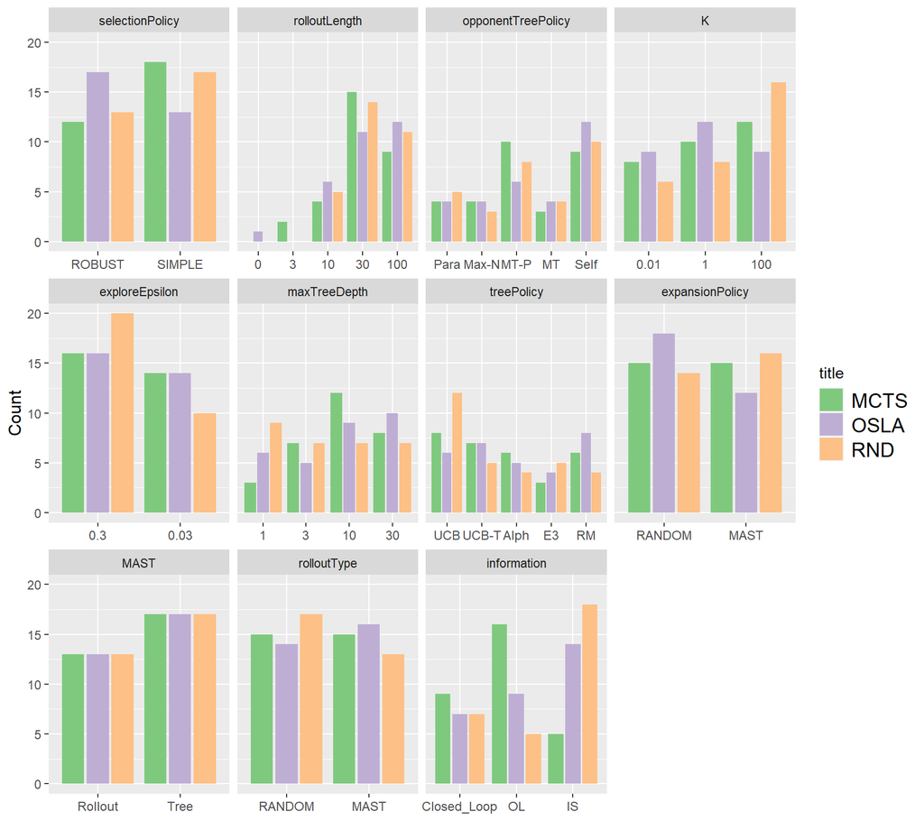

Significant p-Values on Chi-squared test for homogeneity - only extreme values highlighted

| Parameter | MCTS | OSLA | RND | All |
| --- | --- | --- | --- | --- |
| selectionPolicy |  |  |  |  |
| rolloutLength | p < 0.001 | p < 0.001 | p < 0.001 | p < 0.001 |
| opponentTreePolicy |  |  |  |  |
| K |  |  |  |  |
| exploreEpsilon |  |  |  |  |
| maxTreeDepth |  |  |  |  |
| treePolicy |  |  |  |  |
| expansionPolicy |  |  |  |  |
| MAST |  |  |  |  |
| rolloutType |  |  |  |  |
| information |  |  |  |  |

### 4P

Mean Win rate over all NTBEA runs

| Type | MCTS | OSLA | RND |
| --- | --- | --- | --- |
| Win Rate | 25% | 31% | 31% |

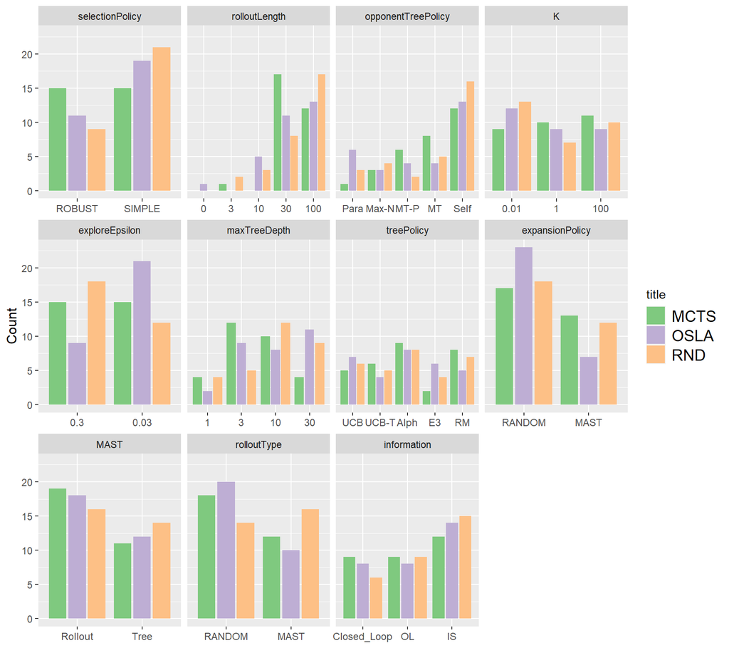

Significant p-Values on Chi-squared test for homogeneity - only extreme values highlighted

| Parameter | MCTS | OSLA | RND | All |
| --- | --- | --- | --- | --- |
| selectionPolicy |  |  |  |  |
| rolloutLength | p < 0.001 | p < 0.001 | p < 0.001 | p < 0.001 |
| opponentTreePolicy |  |  | p < 0.001 | p < 0.001 |
| K |  |  |  |  |
| exploreEpsilon |  |  |  |  |
| maxTreeDepth |  |  |  |  |
| treePolicy |  |  |  |  |
| expansionPolicy |  |  |  |  |
| MAST |  |  |  |  |
| rolloutType |  |  |  |  |
| information |  |  |  |  |